# Expectation & Variance Chapters 3 & 4

## Data types

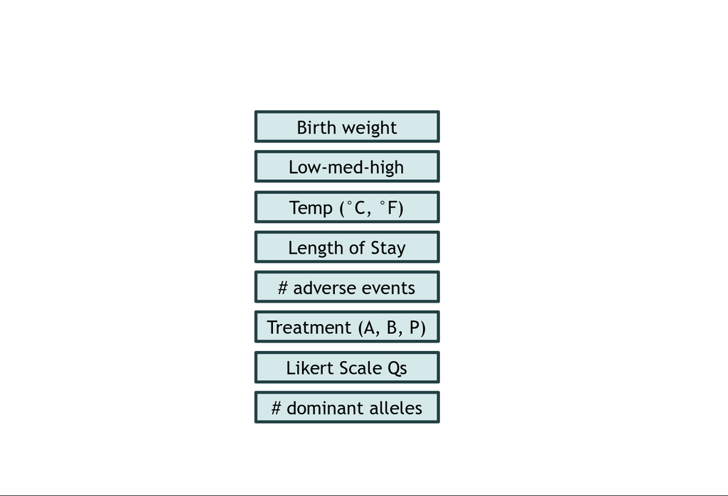

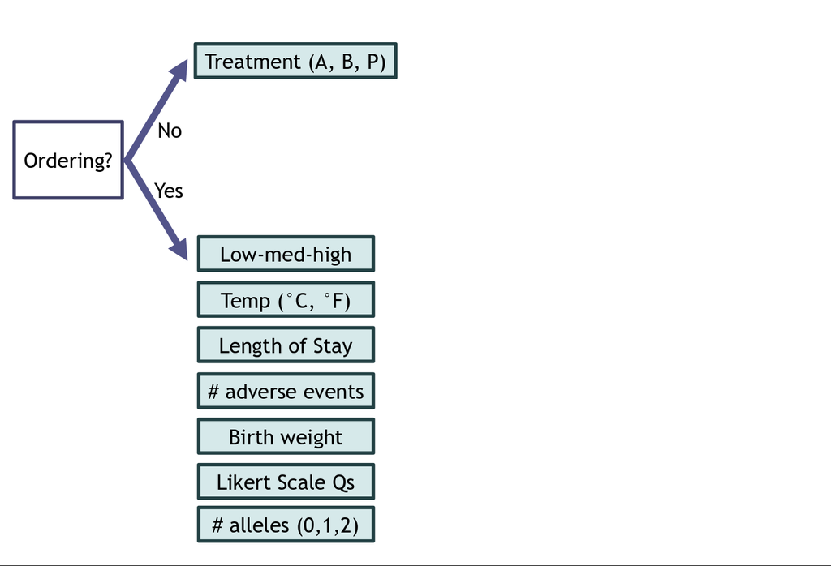

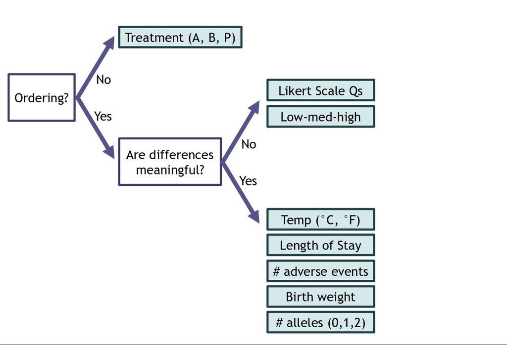

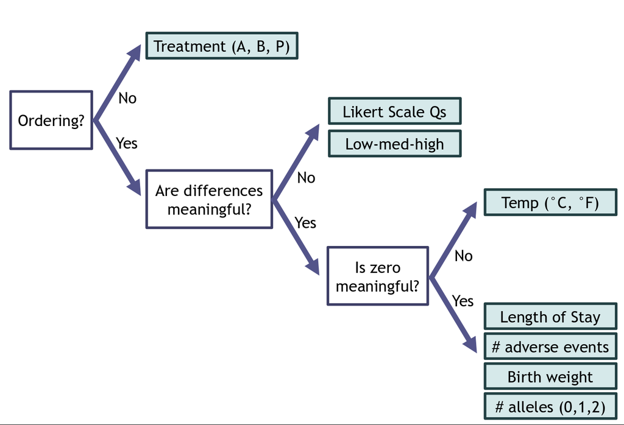

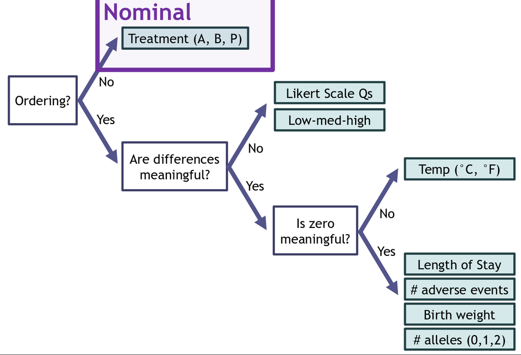

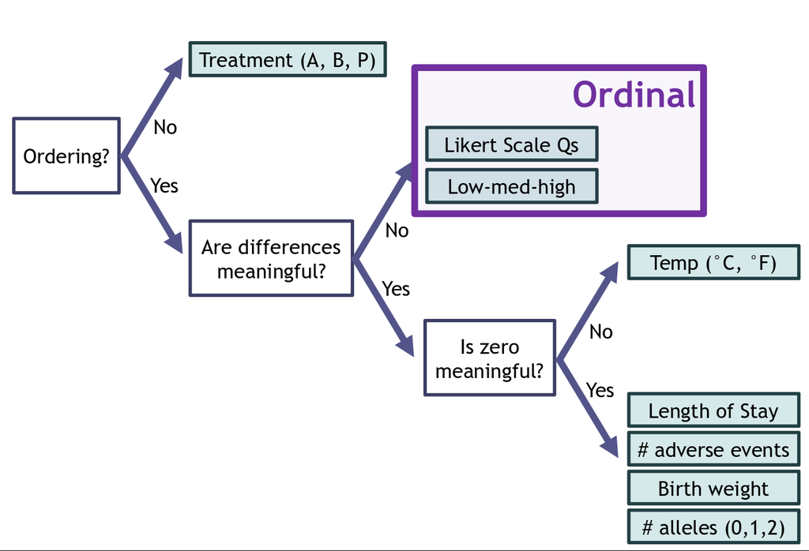

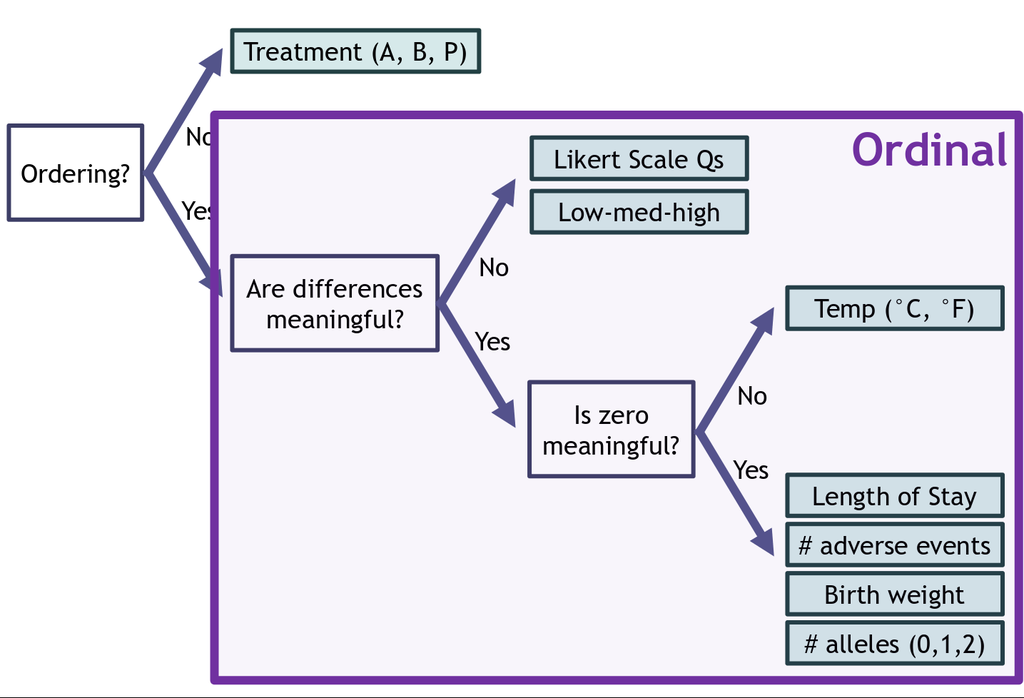

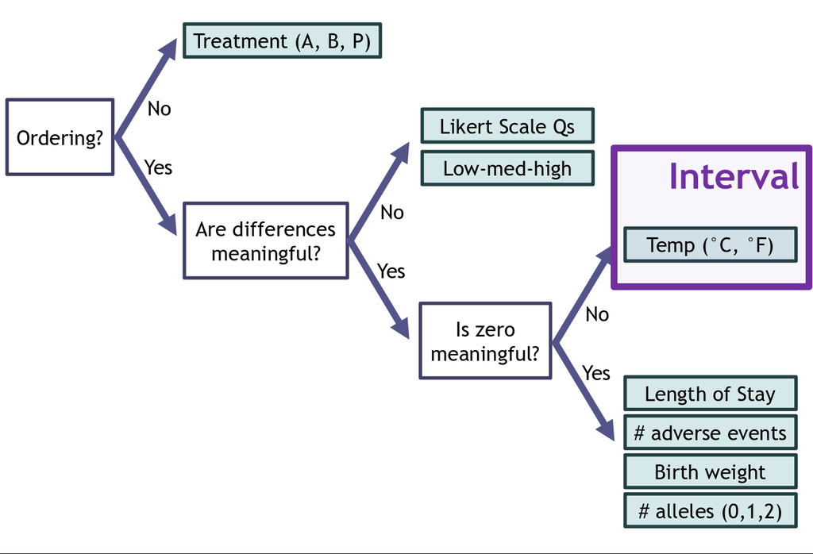

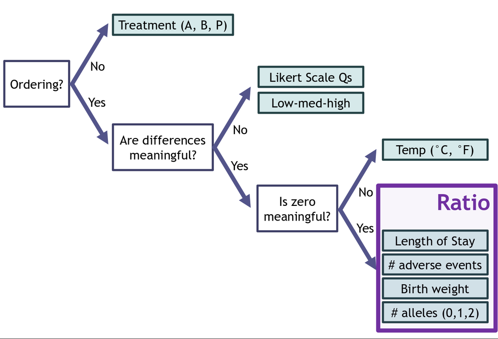

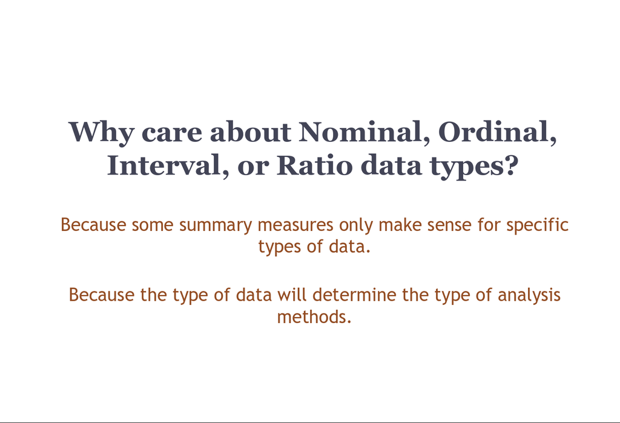

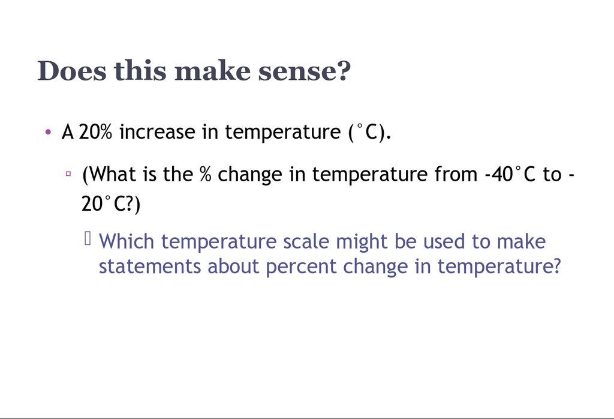

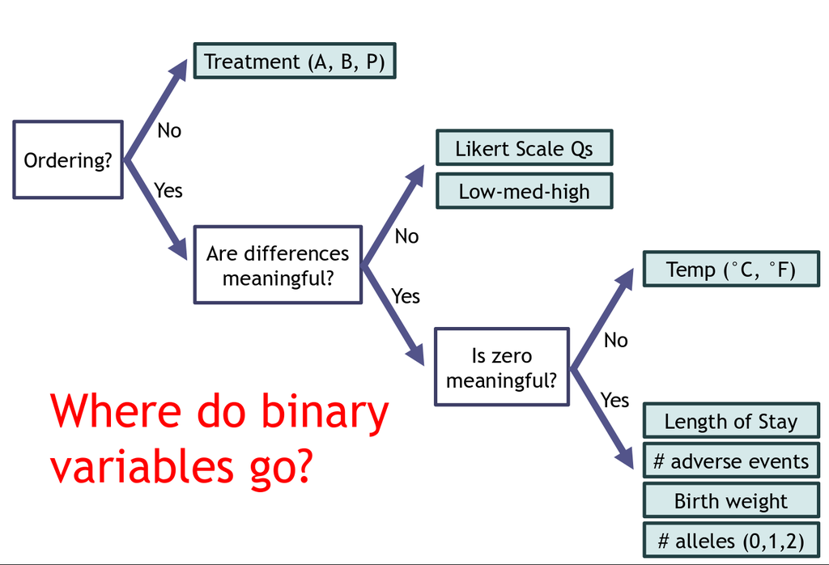

[12 more figures not shown]

## Summary of distribution vs summary of a sample

| Summary Measure | Distribution | Sample |
| --- | --- | --- |
| Median |  |  |
| Mean (expectation) |  |  |
| Variance |  |  |
| IQR |  |  |
| Length of middle 95% |  |  |

## Summary of distribution vs summary of a sample

| Summary Measure | Distribution | Sample |
| --- | --- | --- |
| Median | \(x \text{ such that } P(X\leq x)=P(X>x)=0.5\) | Middle value in sample |
| Mean (expectation) |  |  |
| Variance |  |  |
| IQR |  |  |
| Length of middle 95% |  |  |

## Summary of distribution vs summary of a sample

[output not shown]

## Summary of distribution vs summary of a sample

[output not shown]

## Summary of distribution vs summary of a sample

[output not shown]

## Summary of distribution vs summary of a sample

[output not shown]

## Quantile function

If \(F_X(x)\) is the CDF of a random variable \(X\), then \[ F_X(a) = P(X\leq a) \]

## Quantile function

If \(F_X(x)\) is the CDF of a random variable \(X\), then \[ F_X(a) = P(X\leq a) \]

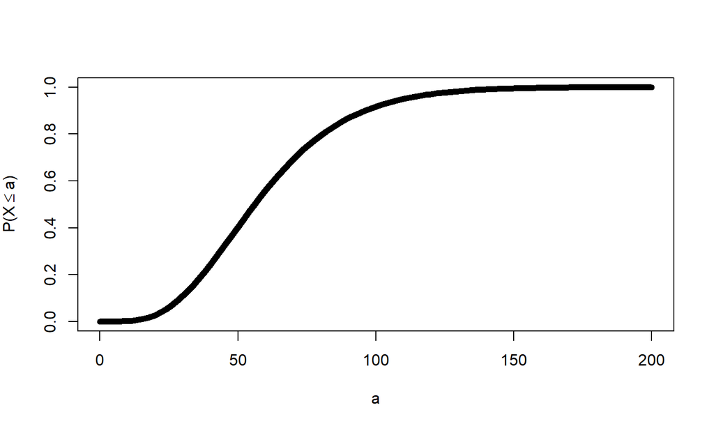

## Quantile function

If \(F_X(x)\) is the CDF of a random variable \(X\), then \[ F_X(a) = P(X\leq a) \]

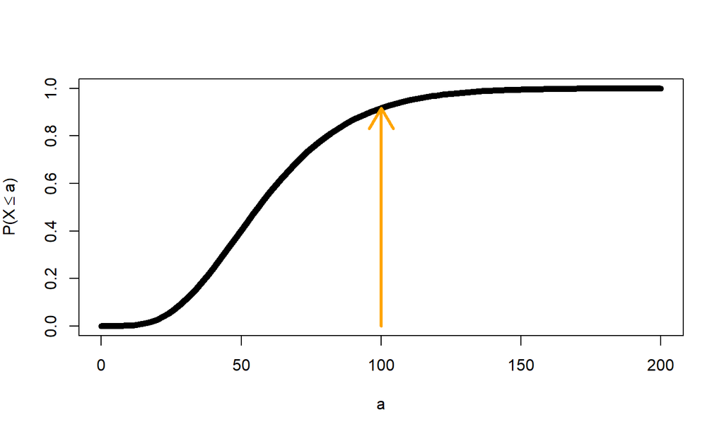

## Quantile function

If \(F_X(x)\) is the CDF of a random variable \(X\), then \[ F_X(a) = P(X\leq a) \]

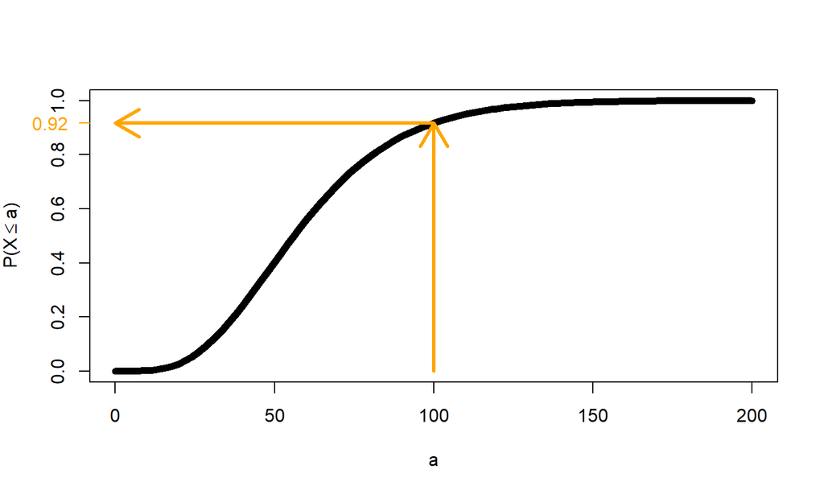

## Quantile function

**The quantile function is the inverse of the CDF**

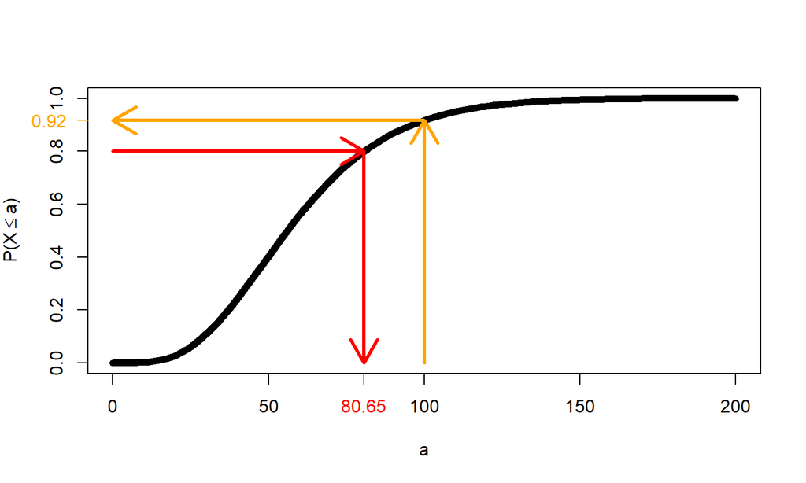

## Notation

\[X_{\alpha} = x \text{ such that } P(X\leq x) = \alpha \]

## In R

- `q`+distribution name

## Practice

- What is the 0.3 quantile of the exponential distribution when \(\lambda = 1\)?
- What is the 0.9 quantile of the normal distribution when \(\mu = 3\) and \(\sigma = 2.4\)?

## Expectation

### The expected value is meaningful for outcomes for which addition and subtraction is meaningful

## Expectation

### The expected value is meaningful for outcomes for which addition and subtraction is meaningful

- Interval variables
- Ratio variables

## Expectation

### The expected value is meaningful for outcomes for which addition and subtraction is meaningful **or binary variables**

- Interval variables
- Ratio variables
- Binary variables (will get to this is a bit)

## Expectation

### The expected value of mutli-category ordinal variables can be meaningful if one assigns **scores** to each candidate outcome.

## Expectation

### The expected value of mutli-category ordinal variables can be meaningful if one assigns **scores** to each candidate outcome.

| Outcome | Score |
| --- | --- |
| Low | 0 |
| Medium | 2 |
| High | 5 |

## Expectation

### The expected value of mutli-category ordinal variables can be meaningful if one assigns **scores** to each candidate outcome.

| Outcome | Score |
| --- | --- |
| Low | 0 |
| Medium | 2 |
| High | 5 |

The selection of **scores** is a researcher decision which can be controversial.

## Expectation

For a random variable \(X\),

### Conceptually & Simulation

\[E[X] = \lim_{n\to\infty} \frac{X_1+X_2+\cdots+X_n}{n}\]

### Mathematically

\[E[X] = \left\{\begin{array}{ll}\sum_x x\,P(X = x) & \text{if discrete} \\ \int x f_X(x)\,dx & \text{if continuous} \end{array}\right.\]

## Expectation

If \(X\) is a Bernoulli random variable,

\[E[X] = 0\cdot P(X = 0) + 1\cdot P(X = 1) = P(X=1) \]

(This is why expectation is meaningful for binary outcomes.)

## Expectation

If \(X\) is a binomial random variable,

\[E[X] = \sum_{x=0}^N x{N \choose x}p^x(1-p)^{(N-x)} \]

What does this simplify to?

## Expectation

If \(X\) is a Poisson random variable,

\[E[X] = \sum_{x=0}^{\infty} x\frac{e^{-\lambda}\lambda^x}{x!} \]

## Expectation

If \(X\) is a uniform random variable,

\[E[X] = \int_{a}^b x(b-a)^{-1}\,dx \]

What does this simplify to?

## Expectation

If \(X\) is a normal random variable,

\[E[X] = \int_{-\infty}^{\infty} x\frac{1}{\sqrt{2\pi\sigma^2}}e^{-\frac{(x-\mu)^2}{\sigma^2}}\,dx \]

What does this simplify to?

## Expectation

- Does not always exist.

## Expectation

- If we create a new random variable with addition, \[ \begin{align*} D &= U + V \\ &\text{then} \\ E[D] &= E[U] + E[V] \end{align*} \]

## Example

\[ \begin{align*} U &= \text{Number of dropped calls in Nashville}\\ V &= \text{Number of dropped calls in Atlanta}\\ D &= U + V \\ &\text{then} \\ E[D] &= E[U] + E[V] \end{align*} \]

## Example

**Note:** The random variables need not be independent.

\[ \begin{align*} U &= \text{Number of dropped calls in Nashville}\\ V &= \text{Number of dropped calls at Vanderbilt}\\ D &= U + V \\ &\text{then} \\ E[D] &= E[U] + E[V] \end{align*} \]

## Expectation

- If we create a new random variable with multiplication, \[ \begin{align*} &\text{ If } U \text{ and } V \text{ are independent, and} \\ &D = U \cdot V \\ &\text{then} \\ &E[D] = E[U] \cdot E[V] \\ \end{align*} \]

## Special case

- If we create a new random variable by multiplying a constant, say \(u\) \[ \begin{align*} &D = u \cdot V \\ &\text{then} \\ &E[D] = E[u] \cdot E[V] = u \cdot E[V] \\ \end{align*} \]

## Example

\[ \begin{align*} &V = \text{Weight time in minutes}\\ &D = \frac{1}{60} \cdot V = \text{Weight time in hours} \\ &\text{then} \\ &E[D] = \frac{1}{60} \cdot E[V] \\ \end{align*} \]

## Expectation

- If we create a new random variable with function transformation, \[ \begin{align*} &D = g(V) \\ &\text{then} \\ &E[D] = E[g(V)] = \left\{\begin{array}{ll} \sum g(v)P(V = v) & \text{if discrete} \\ \int g(v)f_V(v)\, dv & \text{if continuous} \end{array}\right. \\ \end{align*} \]

## Example

- If we create a new random variable with log transformation,

\[ \begin{align*} &V = \text{Number of twitter followers}\\ &D = log(V) \\ &\text{then} \\ &E[D] = E[log(V)] = \sum_{v=0}^{\infty} log(v)P(V = v) \\ \end{align*} \]

## Expecation

Suppose

\[g(V) = (V - E[V])^2\]

## Expecation

The expectation

\[E[g(V)] = E[(V - E[V])^2]\]

is a special quanity called the **variance**.

## Variance

\[\begin{align*} V[X] &= E[(X - E[X])^2]\\ &= E[X^2] - E^2[X]\\ \end{align*}\]

\[\text{Notation: } E^2[X] = (E[X])^2\]

## Variance

If \(c\) is a constant and \(U\) is a random variable,

- What is \(V[cU]\)?
- What is \(V[c + U]\)?

If \(U\) and \(W\) are independent random variables,

- What is \(V[U + W]\)?

## Another special expecation

### Covariance

\[ COV[U,W] = E\left[\,(U - E[U])\,(W - E[W])\,\right]\]